# Inverted Yield Curves in Motion

by : Chris at Savvy Analytics

Background : Inverted yield curves have been touted as the harbinger of recession.

Goal : This document is just going to visualize a few historical inverted yield curves and animate them so that we can visually see how the yield curve changes in the time period around its’ inversion. This analysis will strictly focus on US treasury yield rates.

Note : This article, like most of mine on R-Pubs, is both instructional and investigative. You can re-create any of these charts and tables from the embedded R code. Click the “Code” button to view.

```r
# Clear Environment and load libraries
# Optional memory clear
rm(list=ls())
# Disable Scientific Notation in printing
options(scipen=999)
# Load libraries
require(tidyverse)
require(quantmod)
require(lubridate)
require(scales)
require(rvest)
require(kableExtra)
require(gganimate)

# Load data using the QuantMod package to retrive historical data
# Minimum Wage and CPI data are provided by the St. Louis Federal Reserve "FRED" system

# Grab the Federal Minimum Wage From FRED
invisible(
  getSymbols(c("DGS3MO", "DGS1", "DGS2", "DGS5", "DGS7",
             "DGS10", "DGS20", "DGS30"), src = "FRED")
)

DFFromSymbol <- function(Symbol, Unit) {
  data.frame(Symbol) %>%
  mutate(Symbol = colnames(.)[1],
         Maturity = ifelse(str_detect(Symbol, "MO"),
                      as.numeric(str_extract(Symbol, "\\d*(?=MO)")),
                      as.numeric(str_extract(Symbol, "\\d*$")) * 12),
         QuoteDate = as.Date(row.names(.), "%Y-%m-%d"),
         TimeUnit = floor_date(QuoteDate, unit = Unit)) %>%
  rename(Value = 1) %>%
  group_by(Maturity, TimeUnit) %>%
  summarise(Value = mean(Value, na.rm = TRUE))
}

PresentationWeekDF <- bind_rows(
  DFFromSymbol(DGS3MO, "week"),
  DFFromSymbol(DGS1, "week"), DFFromSymbol(DGS2, "week"),
  DFFromSymbol(DGS5, "week"), DFFromSymbol(DGS7, "week"),
  DFFromSymbol(DGS10, "week"))

PresentationWeekDFLimits <- PresentationWeekDF %>%
  group_by(Maturity) %>%
  summarise(MaxDate = max(TimeUnit),
            MinDate = min(TimeUnit)) %>%
  mutate(LowerLimit = max(MinDate),
         UpperLimit = min(MaxDate))

PresentationWeekDF <- PresentationWeekDF %>%
  filter(TimeUnit >= PresentationWeekDFLimits$LowerLimit[1] &
         TimeUnit <= PresentationWeekDFLimits$UpperLimit[1])


Inversion <- PresentationWeekDF %>%
  spread(Maturity, Value) %>%
  mutate(InversionStatus = case_when(
    `24` > `120` | `24` > `60` ~ "Inverted",
    TRUE ~ "Normal")) %>%
  dplyr::select(TimeUnit, InversionStatus)

PresentationWeekDF <- PresentationWeekDF %>%
  left_join(Inversion, by = c("TimeUnit"))
```

What is an inverted yield curve? Generally it is when short term rates are higher than long term rates. One of the more popular definitions of an inversion is when the two year rate exceeds the ten year rate. In fact the Federal Reserve tracks that spread here:

https://fred.stlouisfed.org/series/T10Y2Y

First, let’s simply look at the yield curve for the past 24 months from Nov 2023:

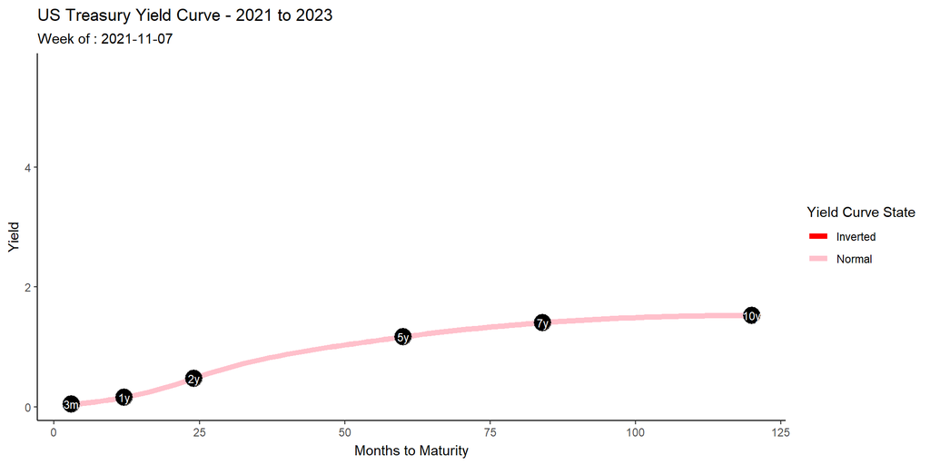

```r
Plot2007 <- PresentationWeekDF %>%
  filter(TimeUnit >= as.Date("2021-11-01") &
         TimeUnit <= as.Date("2023-11-10")) %>%
  mutate(MatLabel = if_else(Maturity < 12, paste0(Maturity, "m"),
                                           paste0(Maturity / 12, "y"))) %>%
  ggplot(aes(Maturity, Value)) +
  geom_smooth(aes(color = InversionStatus), method = "loess", formula = "y ~ x", se=FALSE, linewidth = 2) +
  geom_point(size = 6, color = "black") +
  geom_text(aes(label = MatLabel), color = "white", size = 3) +
  scale_color_manual(values = c("red", "pink")) +
  theme_classic() +
  labs(title = "US Treasury Yield Curve - 2021 to 2023",
       color = "Yield Curve State",
       x = "Months to Maturity",
       y = "Yield")

Plot2007 + transition_time(TimeUnit) +
  labs(subtitle = "Week of : {frame_time}")
```

For historical comparison, let’s also look at a few historical inversions:

The inversion just prior to the 2008 financial crisis:

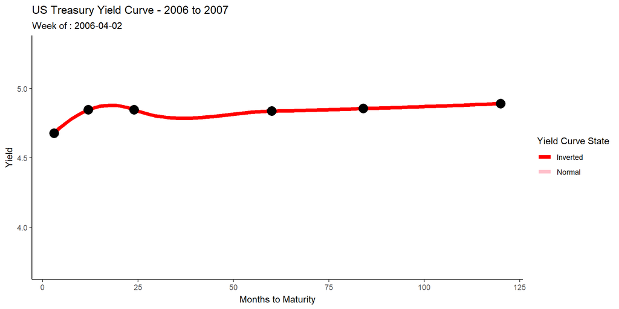

```r
Plot2007 <- PresentationWeekDF %>%
  filter(TimeUnit >= as.Date("2006-04-01") &
         TimeUnit <= as.Date("2007-09-02")) %>%
  mutate(MatLabel = if_else(Maturity < 12, paste0(Maturity, "M"),
                                           paste0(Maturity / 12, "Y"))) %>%
  ggplot(aes(Maturity, Value)) +
  geom_smooth(aes(color = InversionStatus), method = "loess", formula = "y ~ x", se=FALSE, linewidth = 2) +
  geom_point(size = 5, color = "black") +
  scale_color_manual(values = c("red", "pink")) +
  theme_classic() +
  labs(title = "US Treasury Yield Curve - 2006 to 2007",
       color = "Yield Curve State",
       x = "Months to Maturity",
       y = "Yield")

Plot2007 + transition_time(TimeUnit) +
  labs(subtitle = "Week of : {frame_time}")
```

The inversion that burst the Dot Com bubble in 2000:

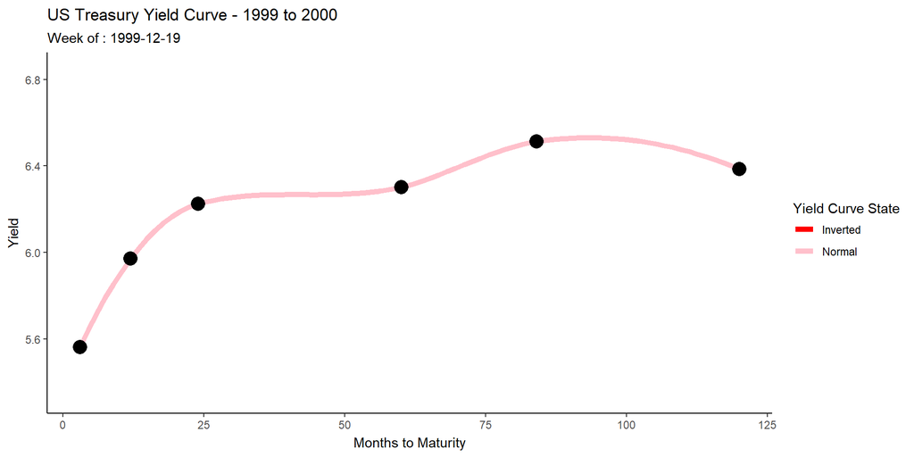

```r
Plot2000 <- PresentationWeekDF %>%
  filter(TimeUnit >= as.Date("1999-12-19") &
         TimeUnit <= as.Date("2000-04-01")) %>%
  mutate(MatLabel = if_else(Maturity < 12, paste0(Maturity, "M"),
                                           paste0(Maturity / 12, "Y"))) %>%
  ggplot(aes(Maturity, Value)) +
  geom_smooth(aes(color = InversionStatus), method = "loess", formula = "y ~ x", se=FALSE, linewidth = 2) +
  geom_point(size = 5, color = "black") +
  scale_color_manual(values = c("red", "pink")) +
  theme_classic() +
  labs(title = "US Treasury Yield Curve - 1999 to 2000",
       color = "Yield Curve State",
       x = "Months to Maturity",
       y = "Yield")


Plot2000 + transition_time(TimeUnit) +
  labs(subtitle = "Week of : {frame_time}")
```

Finally the inversion of 1988:

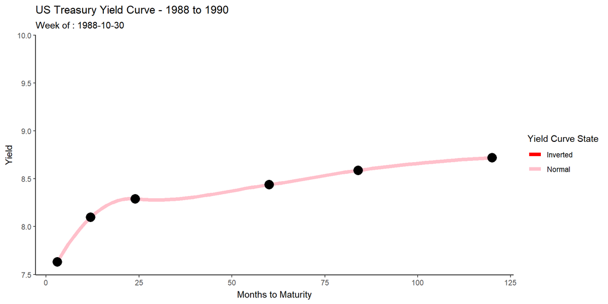

```r
Plot2000 <- PresentationWeekDF %>%
  filter(TimeUnit >= as.Date("1988-10-30") &
         TimeUnit <= as.Date("1990-03-04")) %>%
  mutate(MatLabel = if_else(Maturity < 12, paste0(Maturity, "M"),
                                           paste0(Maturity / 12, "Y"))) %>%
  ggplot(aes(Maturity, Value)) +
  geom_smooth(aes(color = InversionStatus), method = "loess", formula = "y ~ x", se=FALSE, linewidth = 2) +
  geom_point(size = 5, color = "black") +
  scale_color_manual(values = c("red", "pink")) +
  theme_classic() +
  labs(title = "US Treasury Yield Curve - 1988 to 1990",
       color = "Yield Curve State",
       x = "Months to Maturity",
       y = "Yield")


Plot2000 + transition_time(TimeUnit) +
  labs(subtitle = "Week of : {frame_time}")
```

Finally here is the “blinking signal” where the curve inverted and flipped back in late 2019. Finally you can see the rates crash lower and the curve return to normal as the Federal Reserve took action to stimulate the Covid crippled economy in Q1 2020:

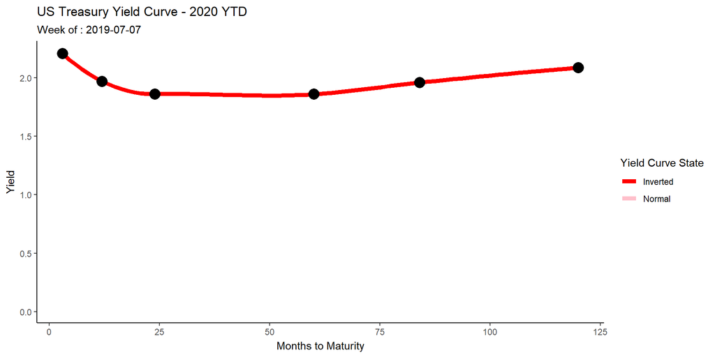

```r
CYPlot <- PresentationWeekDF %>%
  filter(TimeUnit >= as.Date("2019-07-01") &
         TimeUnit <= as.Date("2020-06-01")) %>%
  mutate(MatLabel = if_else(Maturity < 12, paste0(Maturity, "M"),
                                           paste0(Maturity / 12, "Y"))) %>%
  ggplot(aes(Maturity, Value)) +
  geom_smooth(aes(color = InversionStatus), method = "loess", formula = "y ~ x", se=FALSE, linewidth = 2) +
  geom_point(size = 5, color = "black") +
  scale_color_manual(values = c("red", "pink")) +
  theme_classic() +
  labs(title = "US Treasury Yield Curve - 2020 YTD",
       color = "Yield Curve State",
       x = "Months to Maturity",
       y = "Yield")


CYPlot + transition_time(TimeUnit) +
  labs(subtitle = "Week of : {frame_time}")
```

I’m not going to draw any conclusions but I hope you enjoy the dancing yield curves.

Stay savvy